# Decision Trees

# Regression Trees

We fit a regression tree to the Boston data set to predict house price (medv).

First, we create a training set, and fit the tree to the training data.

The output of summary() indicates that only three of the variables have been used in constructing the tree.

The variable lstat measures the percentage of individuals with lower socioeconomic status. We observe that the terminal nodes from the left branch of lstat have higher values than those from the right branch. This indicates that lower values of lstat correspond to more expensive houses.

The tree predicts a median house price of $46,380 for larger homes in suburbs in which residents have high socioeconomic status (rm>=7.437 and lstat<9.715).

```r
summary(tree.boston)
```

```
Regression tree:
tree(formula = medv ~ ., data = Boston, subset = train)
Variables actually used in tree construction:
[1] "lstat" "rm"    "dis"
Number of terminal nodes:  8
Residual mean deviance:  12.65 = 3099 / 245
Distribution of residuals:
     Min.   1st Qu.    Median      Mean   3rd Qu.      Max.
-14.10000  -2.04200  -0.05357   0.00000   1.96000  12.60000
```

We use the cv.tree() function to see whether pruning the tree will improve performance.

However, if we wish to prune the tree, we could do so using the prune.tree() function.

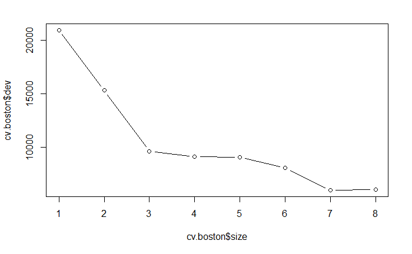

```r
cv.boston=cv.tree(tree.boston)
plot(cv.boston$size, cv.boston$dev, type="b")
```

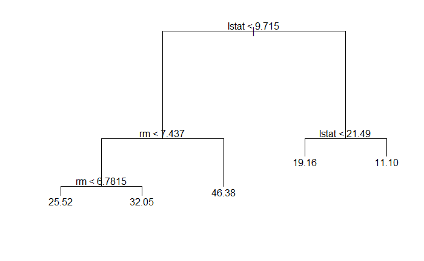

```r
prune.boston=prune.tree(tree.boston ,best=5) #here we obtain the 5-node tree
plot(prune.boston)
text(prune.boston, pretty=0)
```

We use the unpruned tree to make predictions on the test set.

The test set MSE of the unpruned tree is 25.05. The square root of the MSE is therefore 5.005, indicating that this model leads to test predictions that are within $5,005 of the true median home value for the suburb.

```r
yhat=predict(tree.boston, newdata=Boston[-train,])
boston.test=Boston[-train ,"medv"] #response for test set
mean((yhat-boston.test)^2) #test set MSE
```

```
[1] 25.04559
```

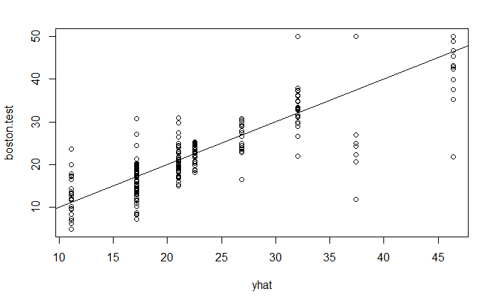

```r
plot(yhat, boston.test) #note that yhat only has 8 distinct values, corresponding to 8 terminal nodes of the tree
abline(0,1)
```

# Bagging and Random Forests

We apply bagging and random forests to the Boston data, using the randomForest package in R.

Recall that bagging is simply a special case of a random forest with m=p. Therefore, the randomForest() function can be used to perform both random forests and bagging.

The argument mtry=13 indicates that all 13 predictors should be considered for each split of the tree. In other words, we want it to perform bagging.

The test set MSE of the bagged regression tree is 13.44, almost half of that obtained using an optimally-pruned single tree (25.05).

```r
library(randomForest)
set.seed(1)
train=sample(1:nrow(Boston), nrow(Boston)/2) #create the training set
bag.boston=randomForest(medv~., data=Boston, subset=train, mtry=13, importance =TRUE)
bag.boston
```

```
Call:
 randomForest(formula = medv ~ ., data = Boston, mtry = 13, importance = TRUE,      subset = train)
               Type of random forest: regression
                     Number of trees: 500
No. of variables tried at each split: 13

          Mean of squared residuals: 10.80817
                    % Var explained: 86.91
```

```r
yhat.bag=predict(bag.boston, newdata=Boston[-train,])
boston.test=Boston[-train ,"medv"] #response for test set
mean((yhat.bag-boston.test)^2) #test set MSE
```

```
[1] 13.444
```

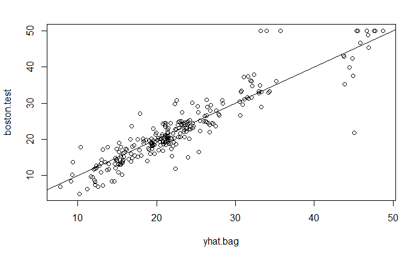

```r
plot(yhat.bag, boston.test) #note that since this bagged tree takes the average response value across 500 trees, yhat of bagged tree has more variety of values compared to the single tree
abline(0,1)
```

We could change the number of trees grown by randomForest() using the ntree argument.

```r
bag.boston=randomForest(medv~., data=Boston, subset=train, mtry=13, ntree=25)
yhat.bag=predict(bag.boston, newdata=Boston[-train,])
mean((yhat.bag-boston.test)^2)
```

```
[1] 13.67774
```

Growing a random forest proceeds in exactly the same way, except that we use a smaller value of the mtry argument.

The test set MSE is 11.66. This indicates that random forests yields an improvement over bagging in this case (13.44).

```r
set.seed(1)
rf.boston=randomForest(medv~., data=Boston, subset=train, mtry=6, importance=TRUE) #here we use m=6
yhat.rf=predict(rf.boston, newdata=Boston[-train,])
mean((yhat.rf-boston.test)^2)
```

```
[1] 11.66454
```

Using the importance() function, we can view the importance of each importance() variable.

Two measures of variable importance are reporte: - %IncMSE is the mean decrease of accuracy (increase in MSE) in predictions on the out of bag samples when a given variable is excluded from the model - IncNodePurity is a measure of the total increase in node purity that results from splits over that variable, averaged over all trees

In the case of regression trees, the node impurity is measured by the training RSS, and for classification trees by the deviance.

Plots of these importance measures can be produced using the varImpPlot() function.

```r
importance(rf.boston)
varImpPlot(rf.boston)
```

[output not shown]

# Boosting

We use the gbm() function from the gbm package to fit boosted regression trees to the Boston data set.

We run gbm() with the option distribution=“gaussian” since this is a regression problem; if it were a binary classification problem, we would use distribution=“bernoulli”.

The argument n.trees=5000 indicates that we want 5000 trees, and the option interaction.depth=4 limits the depth of each tree.

```r
library(gbm)
set.seed(1)
boost.boston=gbm(medv~., data=Boston[train,], distribution="gaussian", n.trees=5000, interaction.depth=4)
```

The summary() function produces a relative influence plot and also outputs the relative influence statistics.

We can also produce partial dependence plots for these two variables. These plots illustrate the marginal effect of the selected variables on the response after integrating out the other variables.

```r
summary(boost.boston)

par(mfrow=c(1,2))
plot(boost.boston, i="rm")
plot(boost.boston, i="lstat")
```

[output not shown]

We use the boosted model to predict medv on the test set.

The test MSE of boosted model is 10.81, superior to the test MSE for random forests (11.66) and bagging (13.44).

The default value is 0.001, but this can be easily modified using the shrinkage argument.

```r
yhat.boost=predict(boost.boston, newdata=Boston[-train,], n.trees=5000)
mean((yhat.boost-boston.test)^2)
```

```
[1] 10.81479
```

```r
boost.boston=gbm(medv~., data=Boston[train,], distribution="gaussian", n.trees=5000, interaction.depth=4, shrinkage=0.2, verbose=F) #here we use <U+03BB>=0.2
yhat.boost=predict(boost.boston, newdata=Boston[-train,], n.trees=5000) #we have to include the argument n.trees=5000 if we predict using the gbm model
mean((yhat.boost-boston.test)^2) #using <U+03BB>=0.2 leads to a higher test MSE than <U+03BB>=0.001
```

```
[1] 11.51109
```